# BIO300A_data

Author

Hanif Kawousi

Published

October 27, 2023

For the BIO300A-assignment, we are looking to answer the following question:

how do the different types of linear infrastructure (roads: paved and unpaved) affects the local wildlife in terms of animal abundance.

this is a broad question, but it is relevant yet again today since the Norwegian government has invested in terrestrial windfarms, both that are already functioning and that are yet to be built. In this process, one must expect there to be roads for building and servicing the windfarms. How will this affect the wildlife? Can we exclusively expect negative outcomes? Are there any benefits for wildlife?

In our data, we focus solely on birds and mammals. This is due to the fact that these are the two animal groups we hear mostly about, and also the groups that are likely to be affected the most in terms of migration patterns, visibility, and more (?).

Our data is from dejounge et al 2022: https://onlinelibrary.wiley.com/doi/10.1111/gcb.16450. They provided a metaanalysis spanning from 1973 - 2018. We choose to view the whole spectrum of data, with a few exemptions. We will be only looking at the paved roads: Highway, Paved Road and County Road, and the unpaved roads: Unpaved Road, Gravel Road, Dirt Road. In doing so we can assess whether or not there is a pattern specific to the paved vs unpaved type roads, and if there are differences within the categories.

our null-Hypothesis is as follows: There are no significant differences in how the different types of roads affects the presence of surrounding wildlife.

The background for our hypothesis is the ongoing debate in Norway regarding the building of landbased windmills, powerlines, roads, etc., and in the cost this will have on nature. Many argue that pristine landscapes will be permanently damaged and that it is the wildlife that will pay the dire price, and in extent the stakeholders. Although, there is a long tradition for cabins amongst scandinavians. Small villages of cabins are often built where there previously were none, and the building of roads where cars can travel have therefore also been built for cabin access. This presents us with an issue: How does these roads differ in the impact on the surrounding mobile wildlife (non-vegetation)?

Therefore, we want to know based on the metastudy of Dejonge et als data, in what sense does infrastructures affect wildlife presence? Is this more or less than average unpaved roads made for recreational trekking and the like?

We will use a two way Anova-test for our statistical analysis. Here, we will look at animal abundance in the areas of the roads and the control areas. This is calculated by the average number of animals per site.

importing libraries

```r
library(tidyverse)
library(readr)
library(tidyr)
library(dplyr)
library(patchwork)
library(stats)
```

importing data

```r
dejonge_dataset <- read_csv("data/dejonge_data/2022_deJonge_Dataset_092022.csv")|>
                                select(StudyYear, Country, Longitude, Latitude,
                                       Group, SpeciesName, AbundanceUnit,
                                       InfraAbundance_original,
                                       ControlAbundance_original, InfraA,
                                       ControlA, InfraN, ControlN,
                                       InfraType, Dist, CDist, MinDist,
                                       MaxDist, MinCDist, MaxCDist) |>
  na.omit(dejonge_dataset)
#abundance. We use this function in the anova-model below, as well as the boxplot.
dejonge_dataset_abundance <- subset(dejonge_dataset, InfraType %in% c("Highway", "Paved road", "County Road", "Unpaved road", "Dirt Road", "Gravel Road")) |>
  select(StudyYear, Country, Group, InfraA, ControlA, InfraType)

dejonge_dataset_abundance <- subset(dejonge_dataset_abundance, Group %in% c("Mammals", "Birds"))

dejonge_dataset_abundance <- mutate(dejonge_dataset_abundance, Difference = InfraA - ControlA)






mammals_birds_data <- subset(dejonge_dataset, Group %in% c("Mammals", "Birds"))

paved_roads_abundance <- subset(mammals_birds_data, InfraType %in% c("Highway", "Paved road", "County road"))

unpaved_roads_abundance <- subset(mammals_birds_data, InfraType %in% c("Unpaved road", "Gravel road", "Dirt road"))
```

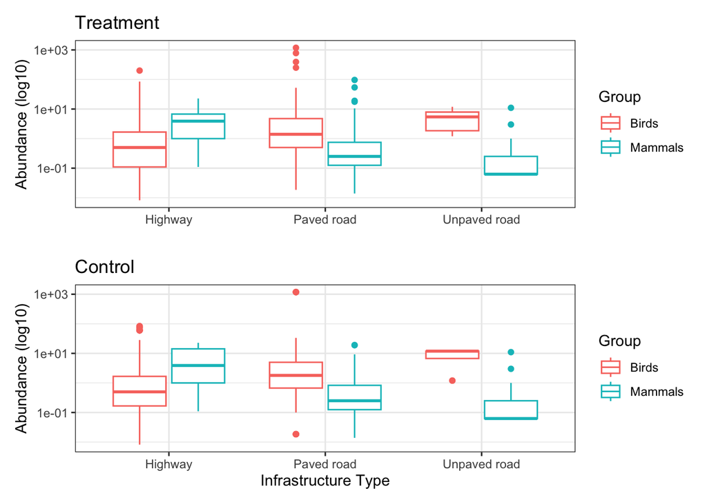

```r
#graphic:  Abundance of Animals by Infrastructure Type
abundance_infratype_boxplot <- ggplot(dejonge_dataset_abundance,
                            aes(x = InfraType,
                                y =  InfraA, color = Group)) +
  geom_boxplot() +
  labs(x = "", y = "Abundance (log10)", fill = "Group") +
  ggtitle("Treatment") +
  theme_bw()

#graphic display:
abundance_infratype_boxplot_C <- ggplot(dejonge_dataset_abundance,
                            aes(x = InfraType,
                                y =  ControlA, color = Group)) +
  geom_boxplot() +
  labs(x = "Infrastructure Type", y = "Abundance (log10)", fill = "Group") +
  ggtitle("Control") +
  theme_bw()


(abundance_infratype_boxplot + scale_y_log10()) / (abundance_infratype_boxplot_C + scale_y_log10())
```

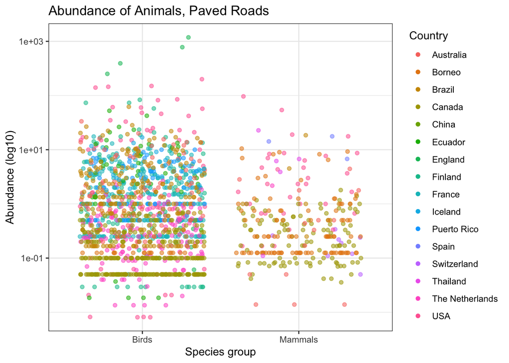

```r
paved_abundance_plot <- ggplot(paved_roads_abundance,
                            aes(x = Group,
                                y =  InfraA, color = Country, alpha = 0.3)) +
  geom_jitter() +
  labs(x = "Species group", y = "Abundance (log10)", fill = "Species group") +
  ggtitle("Abundance of Animals, Paved Roads") +
  theme_bw()


unpaved_abundance_plot <- ggplot(unpaved_roads_abundance,
                            aes(x = Group,
                                y =  InfraA, color = Country, alpha = 0.3)) +
  geom_jitter() +
  labs(x = "Species group", y = "Abundance (log10)", fill = "Species group") +
  ggtitle("Abundance of Animals, Unpaved Roads") +
  theme_bw()

paved_plot <- paved_abundance_plot + scale_y_log10() + scale_fill_viridis_d()
unpaved_plot <- unpaved_abundance_plot + scale_y_log10() + scale_fill_viridis_d()


paved_plot + guides(alpha = FALSE)
```

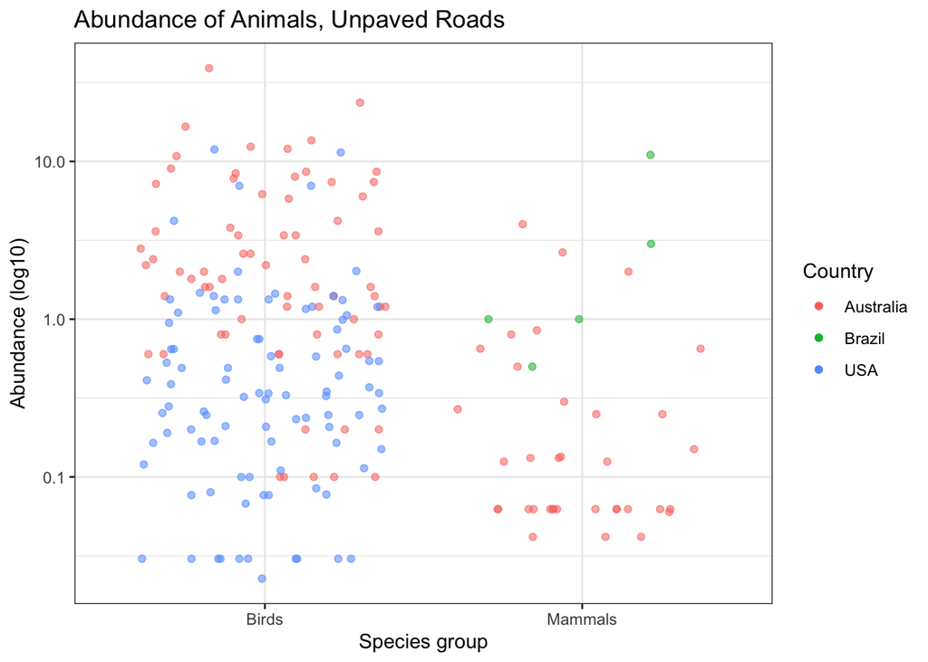

```r
unpaved_plot + guides(alpha = FALSE)
```

```r
#making combined plot for two way anova aov-model:

# Combine the datasets
combined <- rbind(paved_roads_abundance, unpaved_roads_abundance)

# Perform the two-way ANOVA
model <- aov(InfraA ~ Group + factor(InfraType), data = combined)

# Print the ANOVA table
summary(model)
```

```
                    Df  Sum Sq Mean Sq F value   Pr(>F)
Group                1    2717    2717   2.158    0.142
factor(InfraType)    5   40843    8169   6.489 5.45e-06 ***
Residuals         1873 2357960    1259
---
Signif. codes:  0 '***' 0.001 '**' 0.01 '*' 0.05 '.' 0.1 ' ' 1
```

```r
#NOT USING THIS:
##making a model for "difference"-column in dejonge_dataset_anundence. t.test:
#
#t_test_dataset <- data.frame(
#    treatment_abundance = c(paved_roads_abundance$InfraA, unpaved_roads_abundance$InfraA),
#    control_abundance = c(paved_roads_abundance$ControlA, unpaved_roads_abundance$ControlA)
#)
#
#
#print("---------------")
#
## Reshape the data into a long format
#t_test_dataset_long <- t_test_dataset %>%
#  pivot_longer(cols = everything(), names_to = "Group", values_to = "Abundance")
#
## Perform independent samples t-test
#t_test_result <- t.test(Abundance ~ Group, data = t_test_dataset_long)
#
## Print the results
#print(t_test_result)
```

Our two way anova shows that the p-value < 0.05, meaning that our hypothesis is FALSE! therefore: *There is a significant difference in how the different types of roads, paved and unpaved, affect animal abundance.*

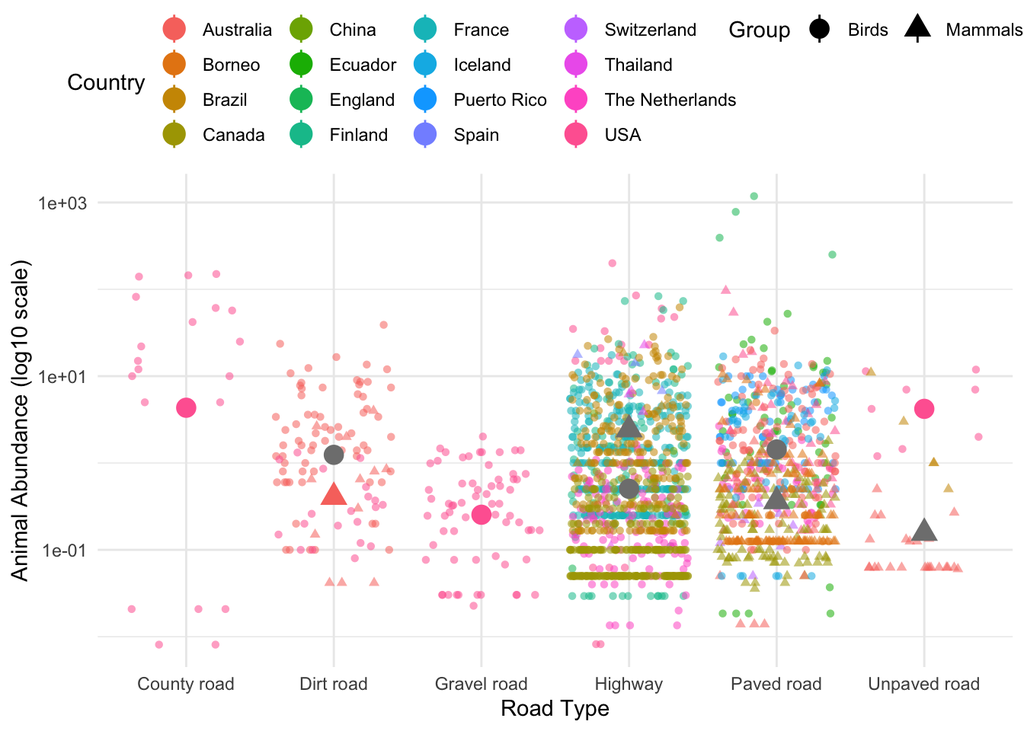

```r
# Calculate the mean abundance for each group
mean_abundance <- combined |>
  group_by(InfraType, Group) |>
  summarize(mean_abundance = mean(InfraA))
# Create a boxplot with log10 scale on y-axis and mean abundance line
all_roads_plot <- ggplot(combined, aes(x = InfraType, y = InfraA, fill = Group, color = Country, shape = Group, alpha = 0.3)) +
  geom_jitter() +
  stat_summary(fun = mean, aes(group = Group), size = 1, alpha = 1) +
  labs(x = "Road Type", y = "Animal Abundance (log10 scale)", fill = "Group") +
  scale_y_log10() +
  theme_minimal() +
  theme(legend.position = "top",
        legend.justification = "left",
        legend.margin = margin(l = -15))

# Display the plot
print(all_roads_plot + guides(alpha = FALSE))
```

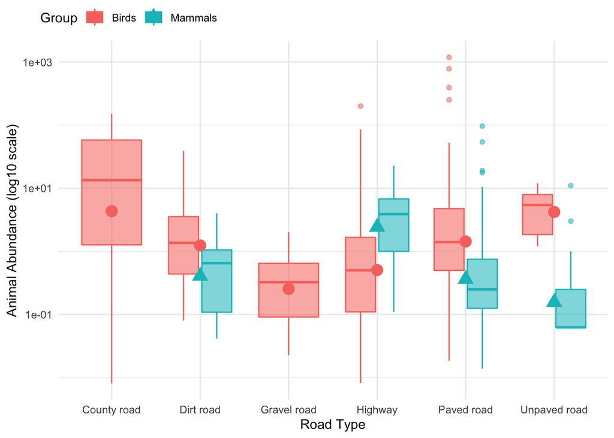

```r
# Calculate the mean abundance for each group
mean_abundance <- combined |>
  group_by(InfraType, Group) |>
  summarize(mean_abundance = mean(InfraA))
# Create a boxplot with log10 scale on y-axis and mean abundance line
all_roads_plot <- ggplot(combined, aes(x = InfraType, y = InfraA, fill = Group, color = Group, shape = Group, alpha = 0.3)) +
  geom_boxplot() +
  stat_summary(fun = mean, aes(group = Group), size = 1, alpha = 1) +
  labs(x = "Road Type", y = "Animal Abundance (log10 scale)", fill = "Group") +
  scale_y_log10() +
  theme_minimal() +
  theme(legend.position = "top",
        legend.justification = "left",
        legend.margin = margin(l = -15))

# Display the plot
print(all_roads_plot + guides(alpha = FALSE))
```